# SVD_Ques5

```python
import pandas as pd
from sklearn.metrics import mean_squared_error
```

```python
df=pd.read_excel('SVD-Data.xlsx',index_col=0)
```

```python
df
```

|  | data | program | complexity | concept | algorithm | processor | game | gene | drug | disease | ... | candidate | optimal | result | training | campaign | win | run | best | expression | sport |
| --- | --- | --- | --- | --- | --- | --- | --- | --- | --- | --- | --- | --- | --- | --- | --- | --- | --- | --- | --- | --- | --- |
| doc1 | 6 | 12 | 3 | 4 | 8 | 2 | 2 | 0 | 0 | 0 | ... | 1 | 2 | 3 | 10 | 0 | 2 | 7 | 6 | 12 | 0 |
| doc2 | 12 | 5 | 5 | 0 | 15 | 2 | 0 | 0 | 0 | 0 | ... | 0 | 6 | 4 | 12 | 0 | 0 | 8 | 6 | 8 | 0 |
| doc3 | 10 | 8 | 4 | 6 | 12 | 4 | 9 | 0 | 0 | 0 | ... | 8 | 8 | 5 | 16 | 0 | 4 | 5 | 2 | 4 | 0 |
| doc4 | 16 | 12 | 7 | 1 | 15 | 6 | 6 | 0 | 0 | 0 | ... | 4 | 12 | 6 | 9 | 0 | 5 | 8 | 4 | 8 | 0 |
| doc5 | 18 | 4 | 4 | 0 | 10 | 4 | 8 | 0 | 0 | 0 | ... | 0 | 6 | 8 | 0 | 0 | 4 | 6 | 6 | 10 | 0 |
| doc6 | 1 | 0 | 4 | 0 | 0 | 0 | 0 | 8 | 12 | 16 | ... | 8 | 0 | 0 | 0 | 0 | 1 | 0 | 4 | 12 | 2 |
| doc7 | 4 | 0 | 0 | 0 | 0 | 0 | 0 | 12 | 15 | 8 | ... | 8 | 0 | 0 | 0 | 0 | 0 | 0 | 0 | 14 | 1 |
| doc8 | 1 | 0 | 2 | 0 | 0 | 0 | 0 | 16 | 4 | 10 | ... | 4 | 2 | 12 | 0 | 0 | 1 | 6 | 5 | 16 | 0 |
| doc9 | 0 | 0 | 0 | 0 | 0 | 0 | 0 | 14 | 6 | 8 | ... | 5 | 0 | 8 | 0 | 0 | 0 | 0 | 8 | 12 | 0 |
| doc10 | 2 | 1 | 4 | 1 | 0 | 0 | 0 | 15 | 9 | 12 | ... | 6 | 0 | 4 | 0 | 0 | 2 | 0 | 5 | 8 | 0 |
| doc11 | 4 | 0 | 5 | 2 | 0 | 0 | 0 | 10 | 7 | 11 | ... | 4 | 1 | 6 | 0 | 0 | 0 | 0 | 4 | 9 | 0 |
| doc12 | 5 | 6 | 0 | 0 | 0 | 0 | 2 | 0 | 0 | 0 | ... | 15 | 1 | 9 | 8 | 10 | 10 | 12 | 8 | 0 | 0 |
| doc13 | 0 | 5 | 0 | 0 | 0 | 0 | 0 | 0 | 0 | 0 | ... | 8 | 0 | 7 | 4 | 12 | 9 | 9 | 10 | 3 | 0 |
| doc14 | 3 | 4 | 1 | 0 | 0 | 0 | 0 | 0 | 10 | 0 | ... | 6 | 0 | 8 | 0 | 9 | 12 | 8 | 4 | 0 | 0 |
| doc15 | 2 | 10 | 0 | 0 | 0 | 0 | 2 | 0 | 8 | 0 | ... | 8 | 0 | 6 | 0 | 8 | 6 | 11 | 9 | 0 | 0 |
| doc16 | 0 | 5 | 1 | 1 | 0 | 0 | 0 | 0 | 6 | 0 | ... | 4 | 0 | 5 | 0 | 12 | 9 | 10 | 9 | 3 | 0 |
| doc17 | 0 | 0 | 2 | 2 | 0 | 0 | 3 | 0 | 4 | 3 | ... | 7 | 0 | 9 | 0 | 10 | 8 | 9 | 3 | 1 | 0 |
| doc18 | 2 | 1 | 2 | 0 | 0 | 0 | 15 | 0 | 0 | 0 | ... | 0 | 6 | 10 | 12 | 0 | 16 | 10 | 6 | 0 | 12 |
| doc19 | 0 | 0 | 3 | 0 | 0 | 0 | 12 | 0 | 2 | 0 | ... | 2 | 4 | 6 | 10 | 2 | 12 | 8 | 8 | 2 | 11 |
| doc20 | 1 | 4 | 0 | 3 | 0 | 0 | 9 | 0 | 4 | 0 | ... | 0 | 2 | 9 | 12 | 2 | 9 | 10 | 8 | 2 | 9 |
| doc21 | 1 | 4 | 3 | 1 | 1 | 0 | 12 | 0 | 2 | 0 | ... | 0 | 6 | 9 | 9 | 1 | 9 | 9 | 6 | 0 | 7 |
| doc22 | 0 | 0 | 0 | 5 | 0 | 0 | 8 | 0 | 0 | 0 | ... | 0 | 8 | 10 | 14 | 0 | 6 | 6 | 9 | 0 | 12 |
| doc23 | 0 | 0 | 0 | 0 | 1 | 0 | 14 | 0 | 1 | 1 | ... | 0 | 0 | 8 | 11 | 0 | 9 | 9 | 8 | 0 | 12 |
| doc24 | 10 | 0 | 0 | 10 | 3 | 0 | 12 | 0 | 0 | 0 | ... | 0 | 0 | 0 | 0 | 0 | 8 | 0 | 0 | 0 | 12 |
| doc25 | 12 | 1 | 2 | 7 | 3 | 0 | 19 | 0 | 0 | 0 | ... | 0 | 0 | 0 | 0 | 0 | 9 | 0 | 0 | 0 | 10 |
| doc26 | 11 | 2 | 1 | 8 | 4 | 0 | 18 | 0 | 0 | 0 | ... | 0 | 4 | 4 | 0 | 0 | 7 | 0 | 0 | 0 | 9 |

26 rows × 22 columns

#### Note: As given dataset/ matrix is not square matrix, so we need to do SVD decomposition to get eigen vectors and eigen values. If we consider given matrix as A.

##### Then svd gives A=U.S.transpose(V).

[output not shown]

#### 5a) Show all the Eigen-values and Eigen-vectors obtained after the decomposition

```python
import numpy as np
U, s, Vh = np.linalg.svd(df) ## considering transpose(v) variable as Vh.
```

```python
print("The eigenvectors of A.transpose(A) are the columns of U matrix = \n")
print( np.round(U, decimals=2))
```

[output not shown]

[output cut: 25 more lines]

```
 [-0.22 -0.16  0.01  0.18 -0.31 -0.05 -0.17 -0.11 -0.13  0.55  0.1  -0.25
   0.08 -0.37 -0.11 -0.02  0.05  0.16 -0.12 -0.04  0.1  -0.39  0.04 -0.05
   0.01  0.02]
 [-0.23 -0.17 -0.02  0.25 -0.18  0.01  0.1  -0.05 -0.12 -0.23 -0.05 -0.18
  -0.35  0.32  0.02 -0.1   0.35 -0.13  0.16  0.14  0.37 -0.14 -0.07  0.18
  -0.17  0.26]
 [-0.13 -0.19  0.11  0.16  0.39 -0.07 -0.01 -0.31 -0.23  0.22 -0.06  0.04
   0.2   0.05 -0.15  0.36  0.1  -0.36  0.01  0.23 -0.16  0.14 -0.33  0.08
  -0.05 -0.03]
 [-0.16 -0.22  0.14  0.17  0.46 -0.02  0.   -0.13 -0.01 -0.21  0.    0.01
  -0.    0.16  0.11 -0.05 -0.13  0.3  -0.12 -0.05  0.18 -0.31  0.02 -0.24
   0.5  -0.05]
 [-0.17 -0.21  0.15  0.13  0.39  0.06 -0.13 -0.08  0.2   0.13  0.08  0.
  -0.1  -0.12  0.07 -0.14  0.16  0.27  0.27 -0.22 -0.11  0.29  0.35  0.09
  -0.37  0.07]]
```

```python
print("The singular values in s are square roots of eigenvalues from A.transpose(A) or transpose(A).A = \n")
print( np.round(s, decimals=2))
```

```
The singular values in s are square roots of eigenvalues from A.transpose(A) or transpose(A).A =

[97.11 58.25 51.3  41.7  31.59 18.23 15.2  13.69 10.86 10.45 10.01  8.88
  8.21  7.37  6.42  5.77  4.2   3.31  2.59  2.36  1.88  1.21]
```

```python
eigen_values=s**2
print("The eigenvalues from A.transpose(A) or transpose(A).A = \n")
print( np.round(eigen_values, decimals=2))
```

```
The eigenvalues from A.transpose(A) or transpose(A).A =

[9.43124e+03 3.39297e+03 2.63214e+03 1.73927e+03 9.98230e+02 3.32360e+02
 2.31010e+02 1.87280e+02 1.17990e+02 1.09260e+02 1.00190e+02 7.88800e+01
 6.73700e+01 5.43500e+01 4.12200e+01 3.33100e+01 1.76400e+01 1.09900e+01
 6.71000e+00 5.58000e+00 3.54000e+00 1.46000e+00]
```

```python
S= np.diag(s)
tmp=np.zeros((4,22))
S=np.concatenate((S,tmp))
print("Matrix S is given by= \n")
print( np.round(S, decimals=2))
```

```
Matrix S is given by=

[[97.11  0.    0.    0.    0.    0.    0.    0.    0.    0.    0.    0.
   0.    0.    0.    0.    0.    0.    0.    0.    0.    0.  ]
 [ 0.   58.25  0.    0.    0.    0.    0.    0.    0.    0.    0.    0.
   0.    0.    0.    0.    0.    0.    0.    0.    0.    0.  ]
 [ 0.    0.   51.3   0.    0.    0.    0.    0.    0.    0.    0.    0.
   0.    0.    0.    0.    0.    0.    0.    0.    0.    0.  ]
 [ 0.    0.    0.   41.7   0.    0.    0.    0.    0.    0.    0.    0.
   0.    0.    0.    0.    0.    0.    0.    0.    0.    0.  ]
 [ 0.    0.    0.    0.   31.59  0.    0.    0.    0.    0.    0.    0.
   0.    0.    0.    0.    0.    0.    0.    0.    0.    0.  ]
 [ 0.    0.    0.    0.    0.   18.23  0.    0.    0.    0.    0.    0.
   0.    0.    0.    0.    0.    0.    0.    0.    0.    0.  ]
 [ 0.    0.    0.    0.    0.    0.   15.2   0.    0.    0.    0.    0.
   0.    0.    0.    0.    0.    0.    0.    0.    0.    0.  ]
 [ 0.    0.    0.    0.    0.    0.    0.   13.69  0.    0.    0.    0.
   0.    0.    0.    0.    0.    0.    0.    0.    0.    0.  ]
 [ 0.    0.    0.    0.    0.    0.    0.    0.   10.86  0.    0.    0.
   0.    0.    0.    0.    0.    0.    0.    0.    0.    0.  ]
 [ 0.    0.    0.    0.    0.    0.    0.    0.    0.   10.45  0.    0.
   0.    0.    0.    0.    0.    0.    0.    0.    0.    0.  ]
 [ 0.    0.    0.    0.    0.    0.    0.    0.    0.    0.   10.01  0.
   0.    0.    0.    0.    0.    0.    0.    0.    0.    0.  ]
 [ 0.    0.    0.    0.    0.    0.    0.    0.    0.    0.    0.    8.88
   0.    0.    0.    0.    0.    0.    0.    0.    0.    0.  ]
 [ 0.    0.    0.    0.    0.    0.    0.    0.    0.    0.    0.    0.
   8.21  0.    0.    0.    0.    0.    0.    0.    0.    0.  ]
 [ 0.    0.    0.    0.    0.    0.    0.    0.    0.    0.    0.    0.
   0.    7.37  0.    0.    0.    0.    0.    0.    0.    0.  ]
 [ 0.    0.    0.    0.    0.    0.    0.    0.    0.    0.    0.    0.
   0.    0.    6.42  0.    0.    0.    0.    0.    0.    0.  ]
 [ 0.    0.    0.    0.    0.    0.    0.    0.    0.    0.    0.    0.
   0.    0.    0.    5.77  0.    0.    0.    0.    0.    0.  ]
 [ 0.    0.    0.    0.    0.    0.    0.    0.    0.    0.    0.    0.
   0.    0.    0.    0.    4.2   0.    0.    0.    0.    0.  ]
 [ 0.    0.    0.    0.    0.    0.    0.    0.    0.    0.    0.    0.
   0.    0.    0.    0.    0.    3.31  0.    0.    0.    0.  ]
 [ 0.    0.    0.    0.    0.    0.    0.    0.    0.    0.    0.    0.
   0.    0.    0.    0.    0.    0.    2.59  0.    0.    0.  ]
 [ 0.    0.    0.    0.    0.    0.    0.    0.    0.    0.    0.    0.
   0.    0.    0.    0.    0.    0.    0.    2.36  0.    0.  ]
 [ 0.    0.    0.    0.    0.    0.    0.    0.    0.    0.    0.    0.
   0.    0.    0.    0.    0.    0.    0.    0.    1.88  0.  ]
 [ 0.    0.    0.    0.    0.    0.    0.    0.    0.    0.    0.    0.
   0.    0.    0.    0.    0.    0.    0.    0.    0.    1.21]
 [ 0.    0.    0.    0.    0.    0.    0.    0.    0.    0.    0.    0.
   0.    0.    0.    0.    0.    0.    0.    0.    0.    0.  ]
 [ 0.    0.    0.    0.    0.    0.    0.    0.    0.    0.    0.    0.
   0.    0.    0.    0.    0.    0.    0.    0.    0.    0.  ]
 [ 0.    0.    0.    0.    0.    0.    0.    0.    0.    0.    0.    0.
   0.    0.    0.    0.    0.    0.    0.    0.    0.    0.  ]
 [ 0.    0.    0.    0.    0.    0.    0.    0.    0.    0.    0.    0.
   0.    0.    0.    0.    0.    0.    0.    0.    0.    0.  ]]
```

```python
print("The eigenvectors of transpose(A).A are the rows of Vh matrix here =  \n")
print( np.round(Vh, decimals=2))
```

```
The eigenvectors of transpose(A).A are the rows of Vh matrix here =

[[-0.25 -0.19 -0.1  -0.1  -0.16 -0.04 -0.33 -0.09 -0.14 -0.09 -0.13 -0.12
  -0.18 -0.16 -0.33 -0.3  -0.14 -0.35 -0.34 -0.29 -0.2  -0.21]
 [-0.09  0.01  0.04 -0.1  -0.09 -0.02 -0.38  0.41  0.34  0.36  0.14  0.12
   0.27 -0.1   0.08 -0.2   0.12 -0.13  0.    0.1   0.38 -0.26]
 [ 0.31 -0.02  0.12  0.09  0.26  0.07  0.16  0.26  0.02  0.21 -0.37 -0.34
  -0.12  0.15 -0.07  0.07 -0.37 -0.21 -0.22 -0.1   0.36  0.07]
 [-0.33 -0.34 -0.09  0.06 -0.43 -0.14  0.33  0.25  0.18  0.23 -0.1  -0.09
  -0.07 -0.14  0.08 -0.08 -0.08  0.2  -0.11  0.03 -0.07  0.43]
 [ 0.48  0.    0.01  0.24  0.05  0.    0.29 -0.03  0.14  0.02  0.21  0.16
   0.13 -0.14 -0.2  -0.56  0.15  0.14 -0.21 -0.24 -0.07  0.02]
 [ 0.13 -0.17 -0.   -0.19 -0.03  0.01  0.02  0.11 -0.35 -0.14 -0.03  0.01
  -0.44  0.03  0.47 -0.49  0.03  0.02  0.16  0.19  0.17 -0.09]
 [-0.04  0.25  0.02 -0.19  0.04 -0.01 -0.06 -0.27  0.53 -0.11 -0.09 -0.09
  -0.45 -0.16 -0.32 -0.15 -0.    0.1   0.2   0.18  0.23  0.16]
 [ 0.06 -0.27  0.27 -0.49  0.05  0.1  -0.   -0.09  0.33  0.11  0.07 -0.14
   0.03  0.39  0.13 -0.04 -0.12  0.23  0.06 -0.31 -0.29 -0.16]
 [-0.21  0.65 -0.08  0.05 -0.23  0.05  0.28  0.24  0.14 -0.2  -0.12 -0.05
   0.03  0.16  0.19 -0.17 -0.19 -0.05  0.01 -0.13 -0.17 -0.27]
 [ 0.03 -0.1  -0.07  0.53  0.09 -0.03 -0.32  0.04  0.37 -0.11  0.18  0.03
  -0.33  0.29  0.33  0.05  0.05 -0.17 -0.12 -0.06 -0.18  0.14]
 [-0.17  0.15  0.44  0.15  0.06  0.03  0.07 -0.2  -0.1   0.53 -0.21  0.23
  -0.13  0.17 -0.05 -0.18  0.11 -0.14 -0.05  0.31 -0.28 -0.02]
 [-0.36  0.01  0.24  0.28  0.06  0.01  0.03 -0.07 -0.15  0.1   0.02  0.02
  -0.22 -0.02  0.    0.05  0.17  0.31  0.12 -0.57  0.38 -0.16]
 [ 0.06  0.21  0.14  0.06 -0.14  0.03 -0.36  0.19 -0.21 -0.06  0.09 -0.38
  -0.01  0.2  -0.18 -0.05  0.11  0.54 -0.33  0.23 -0.05  0.07]
 [ 0.1   0.08  0.18  0.01  0.26 -0.12 -0.04  0.31 -0.    0.13  0.15 -0.13
  -0.25 -0.62  0.09  0.17 -0.14  0.11  0.11 -0.02 -0.4  -0.16]
 [-0.25 -0.22  0.03 -0.08  0.4   0.04  0.25  0.41  0.12 -0.34 -0.16  0.14
  -0.08  0.12 -0.23  0.04  0.39  0.02 -0.17  0.16 -0.07 -0.17]
 [ 0.08  0.08  0.01 -0.03  0.04 -0.07 -0.28  0.39 -0.14 -0.03 -0.22  0.3
   0.02  0.18 -0.27 -0.13 -0.09  0.02  0.47 -0.25 -0.16  0.39]
 [-0.38  0.16 -0.21 -0.17  0.53  0.1   0.04 -0.02 -0.12  0.14  0.43 -0.05
   0.07  0.06  0.05 -0.23 -0.23 -0.02 -0.14 -0.02  0.04  0.34]
 [ 0.05  0.09  0.33 -0.17 -0.18 -0.57  0.19  0.11 -0.09 -0.08  0.45 -0.05
  -0.14  0.19 -0.16  0.11  0.08 -0.33 -0.04 -0.04  0.11  0.08]
 [ 0.03  0.05 -0.36  0.02  0.09 -0.11  0.06 -0.01 -0.03  0.29 -0.07 -0.56
   0.02  0.09 -0.03 -0.08  0.52 -0.16  0.31 -0.09 -0.15 -0.03]
 [-0.16 -0.13  0.51  0.21  0.01  0.23 -0.01 -0.02  0.04 -0.35  0.05 -0.37
   0.34 -0.15  0.04 -0.22 -0.02 -0.22  0.26  0.08 -0.01  0.16]
 [ 0.1   0.17  0.11 -0.26 -0.2   0.59  0.01  0.12 -0.04  0.04  0.08  0.07
  -0.19 -0.14  0.08  0.18  0.37 -0.24 -0.2  -0.21 -0.01  0.3 ]
 [-0.    0.18  0.14 -0.19  0.19 -0.43 -0.16 -0.14  0.07 -0.13 -0.4   0.02
   0.21 -0.17  0.39 -0.05  0.24  0.04 -0.29 -0.17  0.02  0.25]]
```

#### 5b) How many, and which Eigen values (and vectors) would you select if you should preserve 85% of the information?

```python
eigen_values=s**2
percent_contrib=eigen_values/sum(eigen_values)
print("The percent of the each eigen value contributes to valuable information = \n")
print( np.round(percent_contrib, decimals=2))
```

```
The percent of the each eigen value contributes to valuable information =

[0.48 0.17 0.13 0.09 0.05 0.02 0.01 0.01 0.01 0.01 0.01 0.   0.   0.
 0.   0.   0.   0.   0.   0.   0.   0.  ]
```

```python
sum(percent_contrib[:4])
```

```
0.8776413228945918
```

#### Note: Here first 4 eigen values contribute to about 87.76%. So we will consider first four eigen values and corresponding eigen vectors in U and Vh to preserve 85% of the information

```python
new_eigen_values=eigen_values[:4]
print("The new eigenvalues to preserve about 85% information are = \n")
print( np.round(new_eigen_values, decimals=2))
```

```
The new eigenvalues to preserve about 85% information are =

[9431.24 3392.97 2632.14 1739.27]
```

#### After considering first 4 eigen values, the new eigen vectors ( new doc-doc similarity matrix, term-term similarity matrix and concept/ hidden features matrix)

```python
new_s=s[:4]
print("The new singular values in s to preserve about 85% information are = \n")
print( np.round(new_s, decimals=2))
new_S= np.diag(new_s)
print("\nNew Matrix new_S is given by= \n")
print( np.round(new_S, decimals=2))
```

```
The new singular values in s to preserve about 85% information are =

[97.11 58.25 51.3  41.7 ]

New Matrix new_S is given by=

[[97.11  0.    0.    0.  ]
 [ 0.   58.25  0.    0.  ]
 [ 0.    0.   51.3   0.  ]
 [ 0.    0.    0.   41.7 ]]
```

```python
new_U=U[:,:4]
print("The new U matrix to preserve about 85% of information is = \n")
print( np.round(new_U, decimals=2))
```

```
The new U matrix to preserve about 85% of information is =

[[-0.19  0.02  0.14 -0.26]
 [-0.19 -0.02  0.2  -0.37]
 [-0.24 -0.11  0.18 -0.27]
 [-0.27 -0.06  0.24 -0.42]
 [-0.21 -0.03  0.22 -0.25]
 [-0.11  0.33  0.18  0.17]
 [-0.1   0.34  0.2   0.12]
 [-0.16  0.34  0.19  0.13]
 [-0.11  0.31  0.15  0.15]
 [-0.11  0.32  0.17  0.16]
 [-0.11  0.26  0.18  0.1 ]
 [-0.26  0.09 -0.33 -0.14]
 [-0.2   0.12 -0.32 -0.09]
 [-0.19  0.14 -0.3  -0.03]
 [-0.2   0.14 -0.29 -0.1 ]
 [-0.18  0.14 -0.29 -0.05]
 [-0.18  0.13 -0.29  0.01]
 [-0.28 -0.22 -0.02  0.25]
 [-0.23 -0.14 -0.03  0.22]
 [-0.24 -0.1  -0.04  0.15]
 [-0.23 -0.14 -0.01  0.12]
 [-0.22 -0.16  0.01  0.18]
 [-0.23 -0.17 -0.02  0.25]
 [-0.13 -0.19  0.11  0.16]
 [-0.16 -0.22  0.14  0.17]
 [-0.17 -0.21  0.15  0.13]]
```

```python
new_Vh=Vh[:4,:]
print("The new Vh matrix to preserve about 85% of information is = \n")
print( np.round(new_Vh, decimals=2))
```

```
The new Vh matrix to preserve about 85% of information is =

[[-0.25 -0.19 -0.1  -0.1  -0.16 -0.04 -0.33 -0.09 -0.14 -0.09 -0.13 -0.12
  -0.18 -0.16 -0.33 -0.3  -0.14 -0.35 -0.34 -0.29 -0.2  -0.21]
 [-0.09  0.01  0.04 -0.1  -0.09 -0.02 -0.38  0.41  0.34  0.36  0.14  0.12
   0.27 -0.1   0.08 -0.2   0.12 -0.13  0.    0.1   0.38 -0.26]
 [ 0.31 -0.02  0.12  0.09  0.26  0.07  0.16  0.26  0.02  0.21 -0.37 -0.34
  -0.12  0.15 -0.07  0.07 -0.37 -0.21 -0.22 -0.1   0.36  0.07]
 [-0.33 -0.34 -0.09  0.06 -0.43 -0.14  0.33  0.25  0.18  0.23 -0.1  -0.09
  -0.07 -0.14  0.08 -0.08 -0.08  0.2  -0.11  0.03 -0.07  0.43]]
```

```python
A_approx = np.matrix(new_U) * np.diag(new_s) * np.matrix(new_Vh)
print("A calculated using only the first four components:\n")
print(pd.DataFrame(A_approx, index=df.index, columns=df.columns))
print("\nError from actual value:\n")
print(df - A_approx)
```

```
A calculated using only the first four components:

           data     program  complexity   concept  algorithm  processor  \
doc1   10.300120   7.022448    3.813746  1.648384   9.450226   2.853672
doc2   13.076268   8.582204    4.561587  1.937866  12.442253   3.763198
doc3   12.958480   8.039034    4.366933  3.032609  11.517628   3.366585
doc4   16.405203  10.648158    5.668035  2.909362  15.243391   4.561246
doc5   12.234016   7.185908    4.435423  2.552957  10.866573   3.208450
doc6    1.273464  -0.417309    2.324172  0.284109  -0.677866  -0.189951
doc7    1.941640   0.083289    2.520716  0.142339   0.206869   0.101122
doc8    3.076034   1.030567    3.027475  0.700518   0.809186   0.249627
doc9    1.414800   0.020756    2.234253  0.338633  -0.457975  -0.125770
doc10   1.428594  -0.206353    2.309270  0.390279  -0.543345  -0.157602
doc11   2.565974   0.487866    2.404090  0.548642   0.855827   0.259885
doc12   2.362146   7.236292    1.256543 -0.040207   1.758328   0.640977
doc13   0.359501   5.411364    0.621626 -0.516743  -0.013337   0.118409
doc14  -0.543230   4.376802    0.446796 -0.514415  -1.104304  -0.226864
doc15   0.715160   5.526160    0.843207 -0.573060   0.333394   0.234617
doc16  -0.295363   4.535291    0.501611 -0.594773  -0.730971  -0.103188
doc17  -1.187263   3.575878    0.213426 -0.412654  -1.858795  -0.478660
doc18   4.056492   1.496390    1.279971  4.341577   0.714630  -0.165078
doc19   2.800846   1.094697    1.072465  3.372349  -0.037946  -0.306828
doc20   3.558184   2.280137    1.385339  2.981046   1.037545   0.076213
doc21   4.262023   2.337203    1.458746  3.144487   1.856214   0.310119
doc22   3.746627   1.329337    1.246672  3.452722   1.100047   0.035824
doc23   2.503527   0.460891    0.859026  3.622213  -0.443503  -0.465254
doc24   3.860253  -0.035158    1.087562  3.282838   1.678683   0.209310
doc25   5.084177   0.360496    1.449677  3.899431   2.546137   0.423345
doc26   5.902377   1.083090    1.760523  3.844087   3.444693   0.714930

            game       gene     drug     disease  ...  candidate   optimal  \
doc1    3.187141   1.147217  0.944053   0.862010  ...   3.453027  5.450831
doc2    3.269074  -0.087635 -0.483232  -0.305883  ...   2.911816  6.852879
doc3    7.914111  -0.870532 -0.715058  -0.904753  ...   2.376344  7.345221
doc4    6.149106  -0.434719 -0.621048  -0.625079  ...   3.570824  8.846655
doc5    5.834920   1.533301  0.616918   1.145846  ...   2.706234  6.619606
doc6   -0.349529  13.047064  9.413519  11.340862  ...   5.506069  0.019878
doc7   -1.197036  12.790137  9.061465  11.081701  ...   5.471436  0.261492
doc8    0.869710  13.302294  9.926140  11.571774  ...   6.566350  1.070123
doc9    0.040011  11.887834  8.821873  10.352626  ...   5.473241  0.206598
```

[output cut: 176 more lines]

```
doc14 -0.103266
doc15  0.918144
doc16  0.389234
doc17 -0.822499
doc18 -1.264749
doc19  0.322639
doc20  0.112154
doc21 -1.826596
doc22  1.856288
doc23  0.341431
doc24  3.093995
doc25 -0.246424
doc26 -0.530854

[26 rows x 22 columns]
```

#### 5e) Compute the MSE between the original matrix and the predicted matrix using the truncated number of Eigen vectors.

```python
df_list=df.values.tolist()
A_approx_list=pd.DataFrame(A_approx, index=df.index, columns=df.columns).values.tolist()
print("MSE between the original matrix and predcited matrix using the truncated number of eigen vectors: "+str(mean_squared_error(A_approx_list, df_list)))
```

```
MSE between the original matrix and predcited matrix using the truncated number of eigen vectors: 4.191212518402567
```

#### 5d) How many concept vectors are chosen by you in step-b above? Write the intuitive interpretation of each of these vectors. What is the intuitive interpretation of the Eigen-values associated with each of these vectors?

##### Note:

```
* Here I am taking plots for all columns of U and rows of Vh and explaining about few eigen vectors(considered from first 4) with concept strength in the following observations
* Also from abov mean value we can say that as mse is very less, first four eigen values and corresponding eigen vector are much enough to extract useful information. It indicates that with these 4 hidden features/concepts we can summarize the docs and words.
```

#### To help visualize the similarity between words, Vh can be displayed as an image. For example, notice how the similar words (gene and disease, election and vote, sport and game) have similar color values in the first 3 and 4th rows:

#### Observations:

```
* I am just considering (for now) 3 and 4th rows of Vh which are eigen vectors and observed that pair of words like (gene,disease),(election,vote)(sport,game) etc are closely related. So here SVD is trying to get concept vector which learn hidden features/ latent features that explains the concpets that are closely related. Similarly 1 and 2 rows have words which are closely related.
```

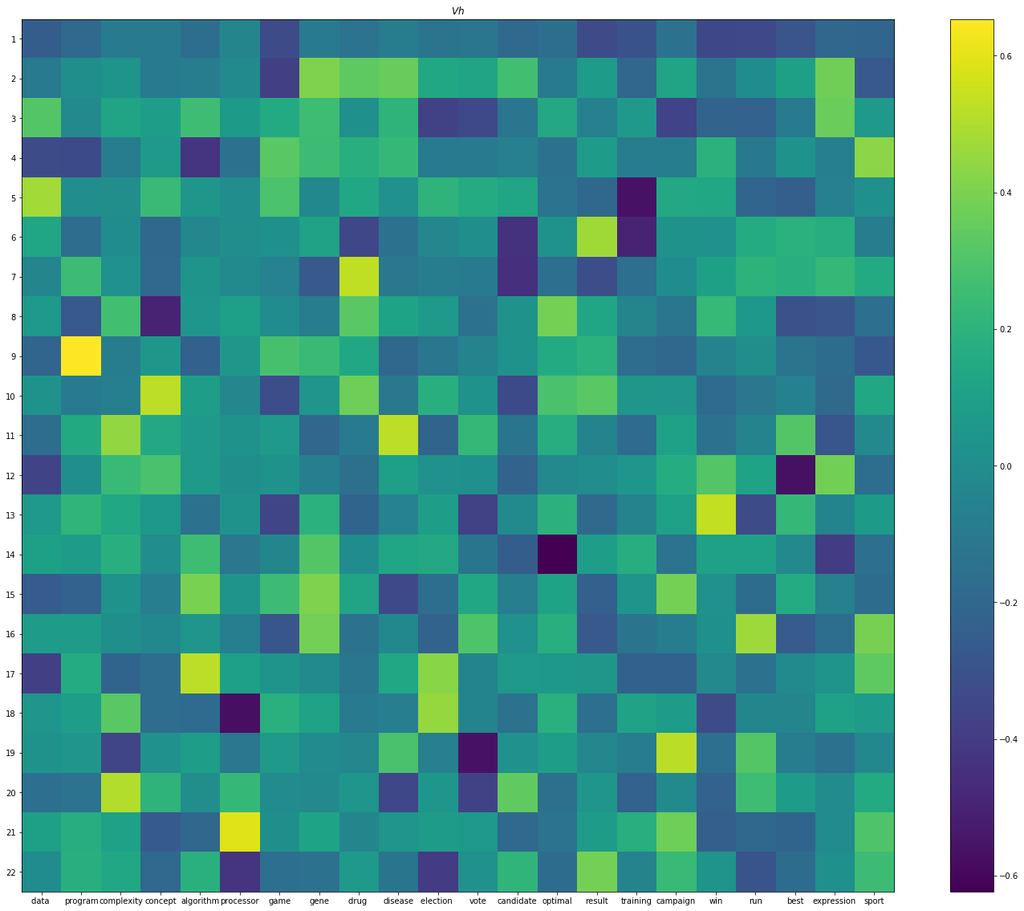

```python
%matplotlib inline
import matplotlib.pyplot as plt
plt.figure(figsize=(25,20))
plt.imshow(Vh, interpolation='none')
plt.xticks(range(len(df.columns)))
plt.yticks(range(len(Vh)))
#plt.ylim([len(Vh) - 1.5, -.5])
ax = plt.gca()
ax.set_xticklabels(df.columns)
ax.set_yticklabels(range(1, len(Vh) + 1))
plt.title("$Vh$")
plt.colorbar();
```

#### Observations:

```
*Recall from:
        ai=u1∗σ1∗(V1,i)+u2∗σ2∗(V2,i)+u3∗σ3∗(V3,i)...
    Thus the words differ very much in how much the values in  u[k]  contribute to their final word count.
*From first 4 columns we can see patterns such that no fluctuating changes that resembles some kind of hidden features for which first 4 docs can be summarised separetly using the concepts/hidden features.
```

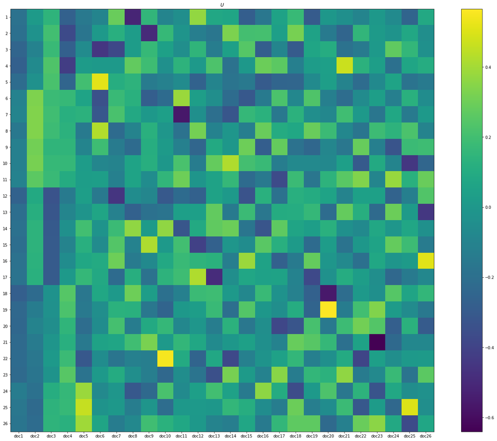

```python
%matplotlib inline
import matplotlib.pyplot as plt
plt.figure(figsize=(25,20))
plt.imshow(U, interpolation='none')
plt.xticks(range(len(df.index)))
plt.yticks(range(len(U)))
#plt.ylim([len(Vh) - 1.5, -.5])
ax = plt.gca()
ax.set_xticklabels(df.index)
ax.set_yticklabels(range(1, len(U) + 1))
plt.title("$U$")
plt.colorbar();
```

#### 5c) Take one of the dropped Eigen-vectors and interpret it in terms of documents and words to show its relevance/irrelevance to the original data table.

```python
dropped_s=s[-1]
dropped_U=U[:,25:26]
#dropped_U.resize(26,1)
dropped_Vh=Vh[21:22,:]
#dropped_Vh.resize(1,22)

A_approx_dropped = np.matrix(dropped_U) * np.matrix(dropped_s) * np.matrix(dropped_Vh)
print("A calculated using only the first four components:\n")
print(pd.DataFrame(A_approx_dropped, index=df.index, columns=df.columns))
print("\nError from actual value:\n")
print(df - A_approx_dropped)
```

```
A calculated using only the first four components:

          data    program  complexity   concept  algorithm  processor  \
doc1  -0.000271  0.019103    0.014709 -0.019401   0.019777  -0.045252
doc2   0.000136 -0.009623   -0.007410  0.009773  -0.009962   0.022795
doc3   0.000114 -0.008006   -0.006165  0.008131  -0.008288   0.018965
doc4  -0.000334  0.023556    0.018138 -0.023923   0.024386  -0.055799
doc5   0.000455 -0.032068   -0.024692  0.032568  -0.033198   0.075963
doc6   0.000174 -0.012299   -0.009470  0.012491  -0.012733   0.029134
doc7  -0.000041  0.002910    0.002241 -0.002956   0.003013  -0.006894
doc8   0.000315 -0.022196   -0.017091  0.022542  -0.022978   0.052579
doc9  -0.000592  0.041728    0.032130 -0.042378   0.043198  -0.098845
doc10  0.000757 -0.053353   -0.041081  0.054185  -0.055233   0.126382
doc11 -0.000900  0.063471    0.048872 -0.064461   0.065708  -0.150351
doc12 -0.000746  0.052595    0.040497 -0.053414   0.054448  -0.124586
doc13  0.001384 -0.097605   -0.075155  0.099126  -0.101044   0.231206
doc14  0.000106 -0.007487   -0.005765  0.007603  -0.007750   0.017734
doc15  0.000437 -0.030825   -0.023735  0.031305  -0.031911   0.073017
doc16 -0.001605  0.113147    0.087122 -0.114911   0.117134  -0.268023
doc17  0.000257 -0.018094   -0.013932  0.018376  -0.018731   0.042861
doc18 -0.000489  0.034487    0.026554 -0.035024   0.035702  -0.081692
doc19  0.000498 -0.035142   -0.027059  0.035690  -0.036380   0.083244
doc20  0.000918 -0.064708   -0.049824  0.065717  -0.066988   0.153280
doc21  0.000253 -0.017836   -0.013734  0.018115  -0.018465   0.042251
doc22 -0.000048  0.003362    0.002589 -0.003415   0.003481  -0.007964
doc23 -0.000822  0.057975    0.044640 -0.058879   0.060018  -0.137332
doc24  0.000096 -0.006746   -0.005195  0.006851  -0.006984   0.015981
doc25  0.000141 -0.009932   -0.007648  0.010087  -0.010282   0.023528
doc26 -0.000230  0.016207    0.012479 -0.016460   0.016778  -0.038391

           game      gene     drug    disease  ...  candidate   optimal  \
doc1  -0.016291 -0.015039  0.006842 -0.013168  ...   0.022083 -0.018062
doc2   0.008206  0.007576 -0.003447  0.006633  ...  -0.011124  0.009098
doc3   0.006827  0.006303 -0.002867  0.005518  ...  -0.009255  0.007570
doc4  -0.020087 -0.018544  0.008437 -0.016237  ...   0.027230 -0.022271
doc5   0.027346  0.025245 -0.011485  0.022104  ...  -0.037070  0.030320
doc6   0.010488  0.009682 -0.004405  0.008478  ...  -0.014218  0.011629
doc7  -0.002482 -0.002291  0.001042 -0.002006  ...   0.003364 -0.002752
doc8   0.018928  0.017474 -0.007950  0.015300  ...  -0.025659  0.020986
doc9  -0.035584 -0.032850  0.014945 -0.028762  ...   0.048237 -0.039453
```

[output cut: 176 more lines]

```
doc14    0.000687   0.010378
doc15    0.002830   0.042728
doc16    2.989610  -0.156841
doc17    1.001661   0.025081
doc18   -0.003167  11.952196
doc19    2.003227  11.048713
doc20    2.005942   9.089696
doc21    0.001638   7.024724
doc22   -0.000309  11.995339
doc23   -0.005324  11.919636
doc24    0.000619  12.009351
doc25    0.000912  10.013768
doc26   -0.001488   8.977534

[26 rows x 22 columns]
```

```python
df_list=df.values.tolist()
A_approx_list_drop=pd.DataFrame(A_approx_dropped, index=df.index, columns=df.columns).values.tolist()
mean_squared_error(A_approx_list_drop, df_list)
```

```
34.25604360428098
```

#### Observation:

```
* Here I am considering last eigen value and corresponding eigen vector in Vh and multiplying to get new predicted matrix using this last concept/eigen value and observed that mse has been increased drastically indicating that does not useful/ contributing to useful information.
* Also if we consider eigen vector or last row in Vh and see its effect on doc1 to doc 17, which can bee seen from error dataframe printed above for the last word sport. (Almost getting zero error for doc1 to doc17)
```

## 5f) Four interpretations of SVD

#### Interpretation 1 :-

```
if A is the document-to-term matrix,
Q: what is AT A?
A: term-to-term ([m x m]) similarity matrix
Q: A AT ?
A: document-to-document ([n x n]) similarity matrix
```

#### Term-to-term Matrix

```python
print( np.round(Vh, decimals=2))
```

```
[[-0.25 -0.19 -0.1  -0.1  -0.16 -0.04 -0.33 -0.09 -0.14 -0.09 -0.13 -0.12
  -0.18 -0.16 -0.33 -0.3  -0.14 -0.35 -0.34 -0.29 -0.2  -0.21]
 [-0.09  0.01  0.04 -0.1  -0.09 -0.02 -0.38  0.41  0.34  0.36  0.14  0.12
   0.27 -0.1   0.08 -0.2   0.12 -0.13  0.    0.1   0.38 -0.26]
 [ 0.31 -0.02  0.12  0.09  0.26  0.07  0.16  0.26  0.02  0.21 -0.37 -0.34
  -0.12  0.15 -0.07  0.07 -0.37 -0.21 -0.22 -0.1   0.36  0.07]
 [-0.33 -0.34 -0.09  0.06 -0.43 -0.14  0.33  0.25  0.18  0.23 -0.1  -0.09
  -0.07 -0.14  0.08 -0.08 -0.08  0.2  -0.11  0.03 -0.07  0.43]
 [ 0.48  0.    0.01  0.24  0.05  0.    0.29 -0.03  0.14  0.02  0.21  0.16
   0.13 -0.14 -0.2  -0.56  0.15  0.14 -0.21 -0.24 -0.07  0.02]
 [ 0.13 -0.17 -0.   -0.19 -0.03  0.01  0.02  0.11 -0.35 -0.14 -0.03  0.01
  -0.44  0.03  0.47 -0.49  0.03  0.02  0.16  0.19  0.17 -0.09]
 [-0.04  0.25  0.02 -0.19  0.04 -0.01 -0.06 -0.27  0.53 -0.11 -0.09 -0.09
  -0.45 -0.16 -0.32 -0.15 -0.    0.1   0.2   0.18  0.23  0.16]
 [ 0.06 -0.27  0.27 -0.49  0.05  0.1  -0.   -0.09  0.33  0.11  0.07 -0.14
   0.03  0.39  0.13 -0.04 -0.12  0.23  0.06 -0.31 -0.29 -0.16]
 [-0.21  0.65 -0.08  0.05 -0.23  0.05  0.28  0.24  0.14 -0.2  -0.12 -0.05
   0.03  0.16  0.19 -0.17 -0.19 -0.05  0.01 -0.13 -0.17 -0.27]
 [ 0.03 -0.1  -0.07  0.53  0.09 -0.03 -0.32  0.04  0.37 -0.11  0.18  0.03
  -0.33  0.29  0.33  0.05  0.05 -0.17 -0.12 -0.06 -0.18  0.14]
 [-0.17  0.15  0.44  0.15  0.06  0.03  0.07 -0.2  -0.1   0.53 -0.21  0.23
  -0.13  0.17 -0.05 -0.18  0.11 -0.14 -0.05  0.31 -0.28 -0.02]
 [-0.36  0.01  0.24  0.28  0.06  0.01  0.03 -0.07 -0.15  0.1   0.02  0.02
  -0.22 -0.02  0.    0.05  0.17  0.31  0.12 -0.57  0.38 -0.16]
 [ 0.06  0.21  0.14  0.06 -0.14  0.03 -0.36  0.19 -0.21 -0.06  0.09 -0.38
  -0.01  0.2  -0.18 -0.05  0.11  0.54 -0.33  0.23 -0.05  0.07]
 [ 0.1   0.08  0.18  0.01  0.26 -0.12 -0.04  0.31 -0.    0.13  0.15 -0.13
  -0.25 -0.62  0.09  0.17 -0.14  0.11  0.11 -0.02 -0.4  -0.16]
 [-0.25 -0.22  0.03 -0.08  0.4   0.04  0.25  0.41  0.12 -0.34 -0.16  0.14
  -0.08  0.12 -0.23  0.04  0.39  0.02 -0.17  0.16 -0.07 -0.17]
 [ 0.08  0.08  0.01 -0.03  0.04 -0.07 -0.28  0.39 -0.14 -0.03 -0.22  0.3
   0.02  0.18 -0.27 -0.13 -0.09  0.02  0.47 -0.25 -0.16  0.39]
 [-0.38  0.16 -0.21 -0.17  0.53  0.1   0.04 -0.02 -0.12  0.14  0.43 -0.05
   0.07  0.06  0.05 -0.23 -0.23 -0.02 -0.14 -0.02  0.04  0.34]
 [ 0.05  0.09  0.33 -0.17 -0.18 -0.57  0.19  0.11 -0.09 -0.08  0.45 -0.05
  -0.14  0.19 -0.16  0.11  0.08 -0.33 -0.04 -0.04  0.11  0.08]
 [ 0.03  0.05 -0.36  0.02  0.09 -0.11  0.06 -0.01 -0.03  0.29 -0.07 -0.56
   0.02  0.09 -0.03 -0.08  0.52 -0.16  0.31 -0.09 -0.15 -0.03]
 [-0.16 -0.13  0.51  0.21  0.01  0.23 -0.01 -0.02  0.04 -0.35  0.05 -0.37
   0.34 -0.15  0.04 -0.22 -0.02 -0.22  0.26  0.08 -0.01  0.16]
 [ 0.1   0.17  0.11 -0.26 -0.2   0.59  0.01  0.12 -0.04  0.04  0.08  0.07
  -0.19 -0.14  0.08  0.18  0.37 -0.24 -0.2  -0.21 -0.01  0.3 ]
 [-0.    0.18  0.14 -0.19  0.19 -0.43 -0.16 -0.14  0.07 -0.13 -0.4   0.02
   0.21 -0.17  0.39 -0.05  0.24  0.04 -0.29 -0.17  0.02  0.25]]
```

#### Document-to-document

```python
print( np.round(U, decimals=2))
```

```
[[-0.19  0.02  0.14 -0.26 -0.15 -0.09  0.29 -0.51  0.16 -0.1  -0.04  0.37
   0.08  0.07 -0.28 -0.16  0.05  0.17 -0.29 -0.   -0.04 -0.1   0.   -0.06
  -0.25  0.09]
 [-0.19 -0.02  0.2  -0.37 -0.17  0.01  0.12  0.02 -0.5   0.17 -0.02 -0.12
  -0.17  0.33  0.21  0.21  0.04  0.32  0.06 -0.15 -0.25  0.15  0.02 -0.02
   0.08 -0.04]
 [-0.24 -0.11  0.18 -0.27 -0.06 -0.45 -0.38  0.03  0.17  0.04 -0.04  0.15
  -0.13  0.05  0.25 -0.28 -0.09 -0.29  0.07  0.11 -0.19 -0.14  0.01  0.27
   0.16 -0.04]
 [-0.27 -0.06  0.24 -0.42  0.02  0.01  0.01  0.28  0.19 -0.03  0.14  0.01
   0.23 -0.19  0.    0.3   0.26 -0.12  0.03  0.04  0.47  0.13  0.04 -0.2
   0.07  0.11]
 [-0.21 -0.03  0.22 -0.25  0.2   0.52  0.11  0.14 -0.14 -0.11 -0.06 -0.26
  -0.1  -0.18 -0.15 -0.3  -0.25 -0.24 -0.06  0.04 -0.1  -0.21 -0.07  0.06
  -0.18 -0.15]
 [-0.11  0.33  0.18  0.17  0.06 -0.34  0.18  0.13 -0.28 -0.22  0.39  0.04
  -0.04 -0.22 -0.31 -0.15  0.23 -0.08  0.23 -0.12 -0.21 -0.06  0.04 -0.12
   0.13 -0.06]
 [-0.1   0.34  0.2   0.12  0.13 -0.31  0.22  0.09  0.    0.04 -0.56 -0.04
  -0.2  -0.32  0.17  0.13 -0.16  0.14 -0.04 -0.08  0.19  0.01 -0.17  0.08
  -0.15  0.01]
 [-0.16  0.34  0.19  0.13 -0.15  0.43 -0.22 -0.1   0.13 -0.   -0.19  0.31
  -0.1  -0.01 -0.12  0.29  0.1   0.08  0.29  0.18 -0.08 -0.17  0.19  0.14
   0.23 -0.1 ]
 [-0.11  0.31  0.15  0.15 -0.1   0.19 -0.14 -0.22  0.11  0.02 -0.12 -0.24
   0.09 -0.    0.3  -0.28  0.28 -0.18 -0.24 -0.09 -0.16  0.28 -0.12 -0.33
   0.18  0.19]
 [-0.11  0.32  0.17  0.16  0.03 -0.09 -0.1   0.06  0.12 -0.    0.22 -0.13
   0.28  0.42  0.21  0.18 -0.13 -0.07 -0.07 -0.08  0.04 -0.3   0.09 -0.1
  -0.45 -0.24]
 [-0.11  0.26  0.18  0.1   0.03  0.04 -0.11  0.06 -0.05  0.15  0.3  -0.01
   0.05  0.16 -0.22 -0.15 -0.36  0.18 -0.17  0.14  0.26  0.34 -0.09  0.38
   0.13  0.29]
 [-0.26  0.09 -0.33 -0.14  0.04 -0.15 -0.45 -0.06 -0.09 -0.3  -0.22 -0.26
   0.05  0.01 -0.33  0.12 -0.19  0.12  0.1   0.06 -0.1   0.04  0.05 -0.26
  -0.12  0.24]
 [-0.2   0.12 -0.32 -0.09 -0.01  0.07 -0.11 -0.27 -0.19 -0.18  0.04  0.04
   0.28 -0.14  0.18 -0.16  0.1   0.11  0.16 -0.22  0.28  0.11 -0.23  0.3
   0.02 -0.44]
 [-0.19  0.14 -0.3  -0.03  0.2  -0.02  0.18  0.37  0.02  0.36 -0.32  0.09
```

[output cut: 23 more lines]

```
 [-0.22 -0.16  0.01  0.18 -0.31 -0.05 -0.17 -0.11 -0.13  0.55  0.1  -0.25
   0.08 -0.37 -0.11 -0.02  0.05  0.16 -0.12 -0.04  0.1  -0.39  0.04 -0.05
   0.01  0.02]
 [-0.23 -0.17 -0.02  0.25 -0.18  0.01  0.1  -0.05 -0.12 -0.23 -0.05 -0.18
  -0.35  0.32  0.02 -0.1   0.35 -0.13  0.16  0.14  0.37 -0.14 -0.07  0.18
  -0.17  0.26]
 [-0.13 -0.19  0.11  0.16  0.39 -0.07 -0.01 -0.31 -0.23  0.22 -0.06  0.04
   0.2   0.05 -0.15  0.36  0.1  -0.36  0.01  0.23 -0.16  0.14 -0.33  0.08
  -0.05 -0.03]
 [-0.16 -0.22  0.14  0.17  0.46 -0.02  0.   -0.13 -0.01 -0.21  0.    0.01
  -0.    0.16  0.11 -0.05 -0.13  0.3  -0.12 -0.05  0.18 -0.31  0.02 -0.24
   0.5  -0.05]
 [-0.17 -0.21  0.15  0.13  0.39  0.06 -0.13 -0.08  0.2   0.13  0.08  0.
  -0.1  -0.12  0.07 -0.14  0.16  0.27  0.27 -0.22 -0.11  0.29  0.35  0.09
  -0.37  0.07]]
```